# Ebola Cumulative Cases Over Time

- Show All Code
- Hide All Code
- View Source

Author

Erik Fink

Published

April 23, 2024

```r
# Load libraries
library(here)
library(tidyverse)
library(lubridate)
```

## Introduction

This analysis aims to visually explore and document the progression of Ebola virus cases during a critical period of the outbreak from August 2014 to March 2015. Focusing on three affected West African countries—Guinea, Liberia, and Sierra Leone—we examine the trends and magnitudes of confirmed cases. By utilizing detailed visualizations, this exercise seeks to provide a clear understanding of how the Ebola epidemic developed over these months, highlighting regional differences in the spread of this devastating disease.

## Data

We analyze the data of confirmed cases of Ebola in Guinea, Liberia, and Sierra Leone as reported by the [World Health Organization](https://reliefweb.int/report/sierra-leone/who-ebola-situation-report-25-november-2015). This comprehensive dataset provides a detailed timeline of the epidemic’s progression, which is crucial for our visualization and interpretation of the outbreak’s impact.

```r
# Read data
data <- readr::read_csv(here("data", "raw", "ebola.csv"))
```

```r
# Process data
# Sort ebola_data by date in ascending order, specifying the dataframe with the column
ebola_data <- data %>%
  arrange(Date)

ebola_graph <- ebola_data %>%
  select(date = Date, country = "Country", cum_conf_cases = Cum_conf_cases)%>%
  filter(date <= ymd("2015-03-15") &
           (country == "Guinea" | country == "Liberia" | country == "Sierra Leone"))

# Calculate minimum and maximum dates
min_date <- min(ebola_graph$date)
max_date <- max(ebola_graph$date)
```

Figure 1 shows the number of laboratory-confirmed cases of Ebola in Guinea, Liberia, and Sierra Leone from August 29, 2014 to März 13, 2015.

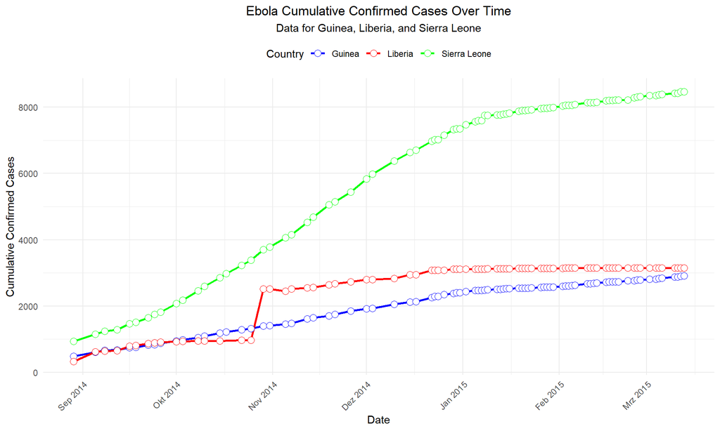

Figure 1: Comparative Analysis of Ebola Virus Disease Spread in Guinea, Liberia, and Sierra Leone (August 2014 - March 2015)

```r
# Creating the plot
ebola_plot <- ggplot(data = ebola_graph, aes(x = date, y = cum_conf_cases, colour = country)) +
  geom_line(aes(group = country), linewidth = 1) +  # Updated to use `linewidth`
  geom_point(size = 3, shape = 21, fill = "white") +  # Add points with white fill
  scale_colour_manual(values = c("Guinea" = "blue", "Liberia" = "red", "Sierra Leone" = "green")) +
  labs(title = "Ebola Cumulative Confirmed Cases Over Time",
       subtitle = "Data for Guinea, Liberia, and Sierra Leone",
       x = "Date",
       y = "Cumulative Confirmed Cases",
       colour = "Country") +
  theme_minimal() +
  theme(plot.title = element_text(hjust = 0.5),
        plot.subtitle = element_text(hjust = 0.5),
        legend.position = "top",
        axis.text.x = element_text(angle = 45, hjust = 1)) +
  scale_x_date(date_breaks = "1 month", date_labels = "%b %Y")  # Adjust x-axis to show monthly breaks

# Display the plot
print(ebola_plot)
```

## Conclusions

Overall, the data indicates a significant increase in confirmed cases of Ebola between August 2014 and March 2015 across three West African countries: Guinea, Liberia, and Sierra Leone. While each country experienced a notable rise in cases, the increase was especially pronounced in Sierra Leone, where the cumulative confirmed cases escalated markedly relative to Guinea and Liberia. This trend underscores the varying impact of the epidemic across different regions and highlights the importance of targeted public health interventions.